# Part I - Prosper Loan Dataset

## Introduction

> Introduce the dataset

This prosper load dataset contains customer data from a loan company named prosper. The dataset has 113,937 observations(loans) with 81 variables. Some of the features include: TotalCreditLinespast7years, LoanStatus, BorrowerAPR, LenderYield, EstimatedReturn, and more

## Preliminary Wrangling

```python
# import all packages and set plots to be embedded inline
import numpy as np
import pandas as pd
import matplotlib.pyplot as plt
import seaborn as sb

%matplotlib inline
```

> Load in your dataset and describe its properties through the questions below. Try and motivate your exploration goals through this section.

```python
#loading the dataset
df = pd.read_csv('prosperLoanData.csv')
df
```

[output not shown]

113937 rows × 81 columns

```python
#accessing the shape of the dataset and its structure
df.shape
```

```
(113937, 81)
```

```python
#get first 5 rows to see what the data looks like
df.head(5)
```

|  | ListingKey | ListingNumber | ListingCreationDate | CreditGrade | Term | LoanStatus | ClosedDate | BorrowerAPR | BorrowerRate | LenderYield | ... | LP_ServiceFees | LP_CollectionFees | LP_GrossPrincipalLoss | LP_NetPrincipalLoss | LP_NonPrincipalRecoverypayments | PercentFunded | Recommendations | InvestmentFromFriendsCount | InvestmentFromFriendsAmount | Investors |
| --- | --- | --- | --- | --- | --- | --- | --- | --- | --- | --- | --- | --- | --- | --- | --- | --- | --- | --- | --- | --- | --- |
| 0 | 1021339766868145413AB3B | 193129 | 2007-08-26 19:09:29.263000000 | C | 36 | Completed | 2009-08-14 00:00:00 | 0.16516 | 0.1580 | 0.1380 | ... | -133.18 | 0.0 | 0.0 | 0.0 | 0.0 | 1.0 | 0 | 0 | 0.0 | 258 |
| 1 | 10273602499503308B223C1 | 1209647 | 2014-02-27 08:28:07.900000000 | NaN | 36 | Current | NaN | 0.12016 | 0.0920 | 0.0820 | ... | 0.00 | 0.0 | 0.0 | 0.0 | 0.0 | 1.0 | 0 | 0 | 0.0 | 1 |
| 2 | 0EE9337825851032864889A | 81716 | 2007-01-05 15:00:47.090000000 | HR | 36 | Completed | 2009-12-17 00:00:00 | 0.28269 | 0.2750 | 0.2400 | ... | -24.20 | 0.0 | 0.0 | 0.0 | 0.0 | 1.0 | 0 | 0 | 0.0 | 41 |
| 3 | 0EF5356002482715299901A | 658116 | 2012-10-22 11:02:35.010000000 | NaN | 36 | Current | NaN | 0.12528 | 0.0974 | 0.0874 | ... | -108.01 | 0.0 | 0.0 | 0.0 | 0.0 | 1.0 | 0 | 0 | 0.0 | 158 |
| 4 | 0F023589499656230C5E3E2 | 909464 | 2013-09-14 18:38:39.097000000 | NaN | 36 | Current | NaN | 0.24614 | 0.2085 | 0.1985 | ... | -60.27 | 0.0 | 0.0 | 0.0 | 0.0 | 1.0 | 0 | 0 | 0.0 | 20 |

5 rows × 81 columns

```python
#an overview of the structure of the data, we can see that there are some missing data
df.info
```

[output not shown]

[output cut: 364 more lines]

```python
#lets create a sub dataframe on variables of interest
interested_variables = ['Term', 'LoanStatus', 'BorrowerAPR', 'ProsperScore', 'ListingCategory (numeric)', 'EmploymentStatus',
                    'EmploymentStatusDuration', 'IsBorrowerHomeowner', 'DebtToIncomeRatio', 'StatedMonthlyIncome', 'LoanOriginalAmount',
                    'LoanOriginationDate', 'MonthlyLoanPayment']
loan_df = df[interested_variables]
```

```python
#view new dataframe info, we can see we have some missing data, to avoid complications, we will just drop missing values
loan_df.info()
```

```
<class 'pandas.core.frame.DataFrame'>
RangeIndex: 113937 entries, 0 to 113936
Data columns (total 13 columns):
Term                         113937 non-null int64
LoanStatus                   113937 non-null object
BorrowerAPR                  113912 non-null float64
ProsperScore                 84853 non-null float64
ListingCategory (numeric)    113937 non-null int64
EmploymentStatus             111682 non-null object
EmploymentStatusDuration     106312 non-null float64
IsBorrowerHomeowner          113937 non-null bool
DebtToIncomeRatio            105383 non-null float64
StatedMonthlyIncome          113937 non-null float64
LoanOriginalAmount           113937 non-null int64
LoanOriginationDate          113937 non-null object
MonthlyLoanPayment           113937 non-null float64
dtypes: bool(1), float64(6), int64(3), object(3)
memory usage: 10.5+ MB
```

```python
loan_df.dropna(inplace = True)
```

```python
loan_df.info()
```

```
<class 'pandas.core.frame.DataFrame'>
Int64Index: 77543 entries, 1 to 113936
Data columns (total 13 columns):
Term                         77543 non-null int64
LoanStatus                   77543 non-null object
BorrowerAPR                  77543 non-null float64
ProsperScore                 77543 non-null float64
ListingCategory (numeric)    77543 non-null int64
EmploymentStatus             77543 non-null object
EmploymentStatusDuration     77543 non-null float64
IsBorrowerHomeowner          77543 non-null bool
DebtToIncomeRatio            77543 non-null float64
StatedMonthlyIncome          77543 non-null float64
LoanOriginalAmount           77543 non-null int64
LoanOriginationDate          77543 non-null object
MonthlyLoanPayment           77543 non-null float64
dtypes: bool(1), float64(6), int64(3), object(3)
memory usage: 7.8+ MB
```

### What is/are the main feature(s) of interest in your dataset?

> I'm most interested in the borowerAPR feature

### What features in the dataset do you think will help support your investigation into your feature(s) of interest?

> Some features that will help my findings include LoanOriginalAmount, MonthlyLoanPayment, LoanStatus, LoantTerm and EmploymentStatus

## Univariate Exploration

> In this section, I will investigate the features of interest using plots
1. Exploring BorrowerAPR

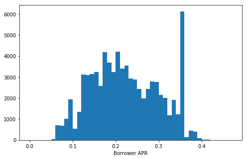

```python
#plotting distribiution
bins = np.arange(0, loan_df.BorrowerAPR.max()+0.05, 0.01)
plt.figure(figsize=[8, 5])
plt.hist(data = loan_df, x = 'BorrowerAPR', bins=bins);
plt.xlabel('Borrower APR');
```

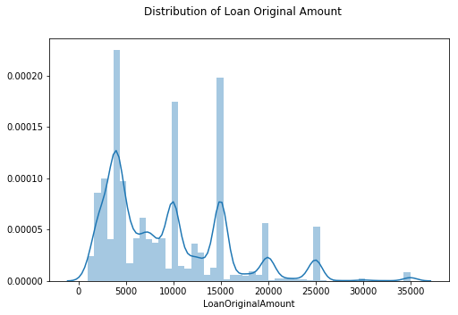

```python
#ploting distribution

plt.figure(figsize=(8,5))
plt.suptitle("Distribution of Loan Original Amount")
sb.distplot(loan_df['LoanOriginalAmount']);
```

```python
#maximum loaned amount
loan_df.LoanOriginalAmount.value_counts().nlargest(1)
```

```
4000    11485
Name: LoanOriginalAmount, dtype: int64
```

```python
#minimum loaned amount
loan_df.LoanOriginalAmount.value_counts().nsmallest()
```

```
10582    1
8263     1
5712     1
18716    1
2388     1
Name: LoanOriginalAmount, dtype: int64
```

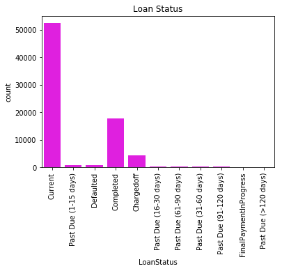

```python
#ploting a countplot
sb.countplot(data = loan_df, x = 'LoanStatus', color = 'magenta');
plt.xticks(rotation = 'vertical')
plt.title("Loan Status");
```

```python
#categorizing loans based on "completed and defaulted"
cat = (loan_df['LoanStatus'] == 'Completed') | (loan_df['LoanStatus'] == 'Chargedoff') | (loan_df['LoanStatus'] == 'Defaulted')
loan_df = loan_df[cat]

def change(row):
    if row['LoanStatus'] == 'Chargedoff':
        return 'Defaulted'
    else:
        return row['LoanStatus']

loan_df['LoanStatus'] = loan_df.apply(change, axis=1)
loan_df['LoanStatus'].value_counts()
```

```
Completed    17700
Defaulted     5329
Name: LoanStatus, dtype: int64
```

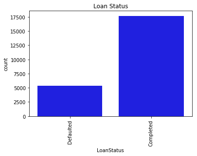

```python
sb.countplot(data = loan_df, x = 'LoanStatus', color = 'blue');
plt.xticks(rotation = 'vertical')
plt.title("Loan Status");
```

> Observation: More people compleated thier loan than those that defaulted.
1. Exploring employment status

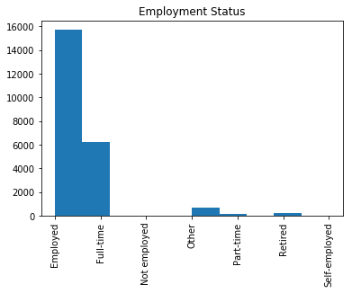

```python
plt.hist(data = loan_df, x = 'EmploymentStatus');
plt.xticks(rotation = 'vertical')
plt.title("Employment Status");
```

> Observation: Majority of the people are employed

### Of the features you investigated, were there any unusual distributions? Did you perform any operations on the data to tidy, adjust, or change the form of the data? If so, why did you do this?

> The loanStatus was a bit unusual because, if we had just observed the loanstatus from the first graph that was ploted, we will see that most categories were overlapping, so I had to group them into two distict groups in order to correctly analyse the status of the loan whether its completed or not.